# Visualizing and animating deflection shapes

**NoteIn this tutorial**

- **You will learn** how to build a measurement mesh, display mode shapes and operational deflection shapes (ODS) on it, and turn them into animations.
- **Prerequisites**: the Getting started page. Basic knowledge of Makie is helpful.
- **Duration**: about 15 minutes.

The visualization tools of `StructuralVibration.jl` are provided by package extensions, which are activated by loading [Makie](https://docs.makie.org/stable/) (any backend) and [Meshes.jl](https://juliageometry.github.io/Meshes.jl/stable/):

```julia
using StructuralVibration, CairoMakie, Meshes   # or GLMakie for interactive 3D views
```

## 1 Step 1 – The structure

We consider a simply supported steel plate of 600 × 400 × 1 mm. The analytical `Plate` model gives its natural frequencies and the corresponding wavenumbers.

```julia
plate = Plate(0.6, 0.4, 1e-3, 2.1e11, 7800., 0.33)   # Lx, Ly, thickness, E, ρ, ν
ωn, kn = modefreq(plate, 300.)[1:2]

# Mode indices (m, n): number of half-waves along x and y
mn = round.(Int, [kn[1, :]*0.6/π kn[2, :]*0.4/π])
for i in 1:6
    println("Mode $i: (m, n) = ($(mn[i, 1]), $(mn[i, 2])), f = ", round(ωn[i]/2π, digits = 1), " Hz")
end
```

```
Mode 1: (m, n) = (1, 1), f = 22.5 Hz
Mode 2: (m, n) = (2, 1), f = 43.3 Hz
Mode 3: (m, n) = (1, 2), f = 69.2 Hz
Mode 4: (m, n) = (3, 1), f = 77.9 Hz
Mode 5: (m, n) = (2, 2), f = 90.0 Hz
Mode 6: (m, n) = (3, 2), f = 124.6 Hz
```

## 2 Step 2 – Building a measurement mesh

A mesh is defined by a matrix of node coordinates (one row per node, columns $x$, $y$, $z$) and a list of elements, each element being the vector of its node indices. Here, we use a regular grid of 13 × 9 points and quadrangular elements.

```julia
using LazyGrids

nx, ny = 13, 9
X, Y = ndgrid(range(0., 0.6, nx), range(0., 0.4, ny))
xp, yp = X[:], Y[:]
nodes = [xp yp zeros(length(xp))]

# Quadrangles, with nodes listed counter-clockwise
function quad_elements(nx, ny)
    elts = Vector{Vector{Int}}()
    for j in 1:(ny - 1), i in 1:(nx - 1)
        n1 = (j - 1)*nx + i
        push!(elts, [n1, n1 + 1, n1 + nx + 1, n1 + nx])
    end
    return elts
end
elts = quad_elements(nx, ny)

mesh = build_mesh(nodes, elts)
```

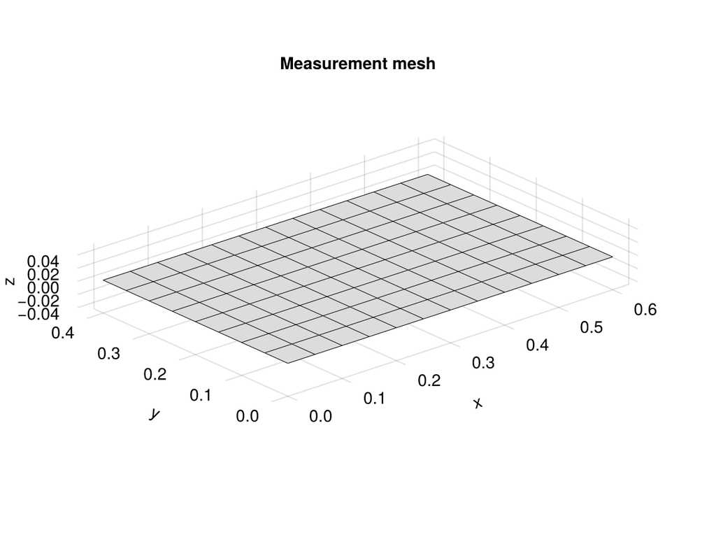

```julia
viz_mesh(mesh, title = "Measurement mesh", zlim = (-0.05, 0.05))
```

**Tip**

Any mesh can be used, including meshes coming from a FE software or from an experimental setup, as long as the nodes are numbered from 1 to the number of nodes. Triangles and quadrangles can be mixed. If the numbering is not contiguous, `renumber_element_connectivity` fixes the connectivity.

## 3 Step 3 – Displaying mode shapes

The mode shapes are evaluated at the nodes of the mesh. To display a deformed mesh, `deformed_grid` needs a displacement vector with three components per node ($u_x$, $u_y$, $u_z$, node after node): for a plate in bending, only $u_z$ is non-zero.

```julia
Φ = modeshape(plate, kn, xp, yp) # One row per node, one column per mode

# Helper: out-of-plane displacement field → 3 components per node
function out_of_plane!(w)
    u = zeros(3length(w))
    u[3:3:end] .= w
    return u
end

function show_shape(w, title; scale = 0.03)
    w = w/maximum(abs, w)                                # Unit maximum
    deformed = deformed_grid(nodes, out_of_plane!(w), scale)
    return viz_mesh(SimpleMesh(deformed, mesh.topology.connec), color = w, title = title,
                    zlim = (-0.05, 0.05))
end
```

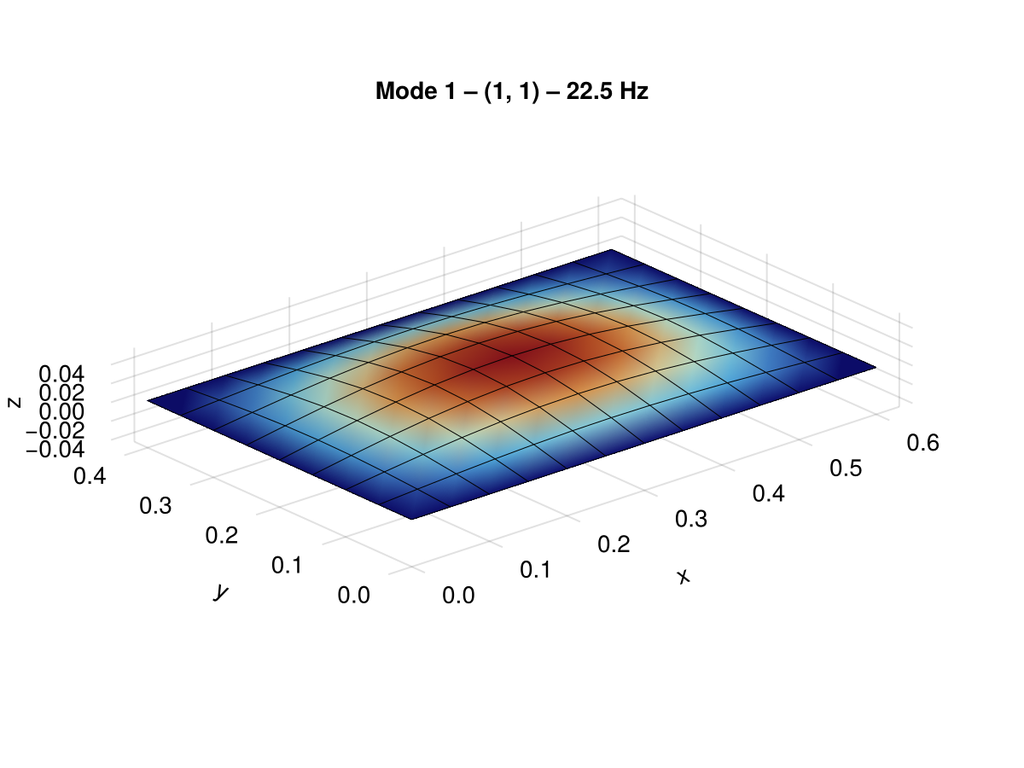

```julia
show_shape(Φ[:, 1], "Mode 1 – (1, 1) – $(round(ωn[1]/2π, digits = 1)) Hz")
```

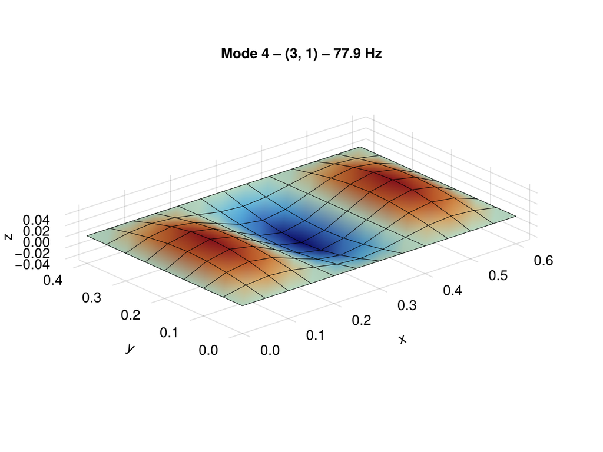

```julia
show_shape(Φ[:, 4], "Mode 4 – (3, 1) – $(round(ωn[4]/2π, digits = 1)) Hz")
```

The color map highlights the nodal lines, where the displacement vanishes. They are the places to avoid when choosing excitation or measurement points.

## 4 Step 4 – Operational deflection shapes

A structure excited at a given frequency does not vibrate according to a single mode shape, but according to an **operational deflection shape** (ODS), which combines the contributions of all the modes. The ODS at frequency $f$ is given by a column of the FRF matrix: the response of all the nodes to a force applied at one point.

```julia
# Point force at (x, y) = (0.15, 0.10) m
i_exc = argmin((xp .- 0.15).^2 .+ (yp .- 0.1).^2)
freq = 1.:0.5:300.
H = solve(ModalFRFProblem(ωn, 0.01, freq, Φ, Φ[i_exc:i_exc, :]), progress = false).u

# ODS at 60 Hz, between modes 2 (43 Hz) and 3 (69 Hz)
i60 = findfirst(>=(60.), freq)
ods_complex = H[:, 1, i60]
ods = real_normalization(reshape(ods_complex, :, 1))[:, 1] # Complex → real shape
```

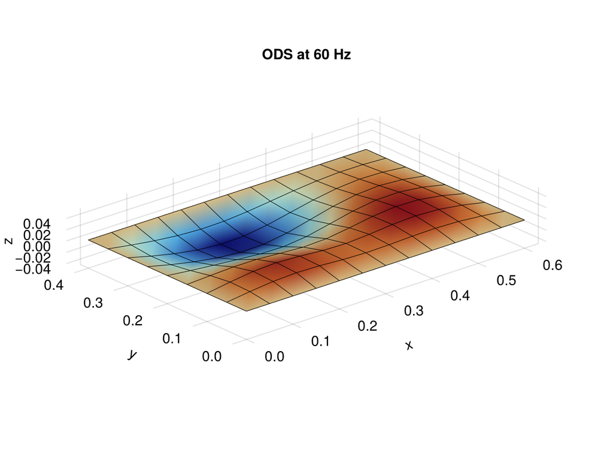

```julia
show_shape(ods, "ODS at 60 Hz")
```

The MAC with each mode shape quantifies the contribution of the modes to the ODS.

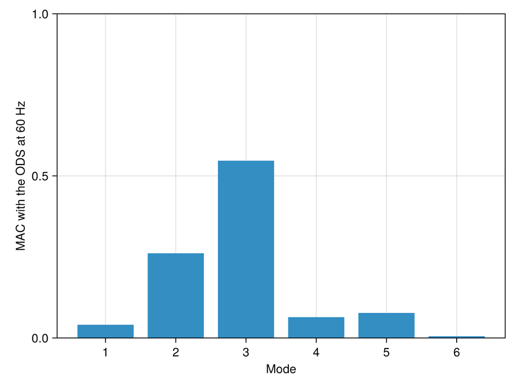

```julia
mac_ods = [mac(ods, Φ[:, k])[1] for k in 1:6]

fig = Figure()
ax = Axis(fig[1, 1], xlabel = "Mode", ylabel = "MAC with the ODS at 60 Hz", xticks = 1:6)
barplot!(ax, 1:6, mac_ods)
ylims!(ax, 0., 1.)
fig
```

The ODS at 60 Hz is dominated by modes 3 and 2, the two modes surrounding the excitation frequency, but neither of them alone describes it. This is why an ODS should never be confused with a mode shape, unless the excitation frequency is very close to an isolated resonance.

## 5 Step 5 – Animating a deflection shape

`animate_mesh` records a video of the harmonic motion of a deflection shape.

```julia
w = ods/maximum(abs, ods)
animate_mesh(nodes, elts, out_of_plane!(w), color = w, scale_factor = 0.03, zlim = (-0.05, 0.05),
             title = "ODS at 60 Hz", framerate = 24, frequency = 4., filename = "plate_ods.mp4")
```

[video not shown]

The same function also animates a time or frequency evolution: if `values` is a matrix with one column per time step (or frequency), and the corresponding vector is given as fourth argument, the title of the video displays the current time (or frequency).

```julia
animate_mesh(nodes, elts, U, t, unit_x = "s", quantity_y = "Time", filename = "response.mp4")
```

**Tip**

With `GLMakie`, the 3D views can be rotated and zoomed interactively, which is very convenient to inspect complex shapes. `CairoMakie` is better suited to static figures for reports.

**Reference pages**: Extensions, Operational deflection shapes, Mechanical models.